# Including covariates in occupancy models

# Plot predicted relationships

We start by creating a sequence of $Rain$ values, rather than doing one a time. Here we use the `seq()` function to create a sequence, which will range from the minimum $Rain$ value to the maximum within our dataset. The number of values that we want in this sequence is specified as 20 but we can choose any value here - we just need enough that the line is drawn “accurately”.

```r
rain <- seq(from = min(det.covs$rain),
            to = max(det.covs$rain),
            length.out = 20)

rain
```

```
##  [1] -2.71815687 -2.44127881 -2.16440076 -1.88752271 -1.61064465 -1.33376660
##  [7] -1.05688855 -0.78001049 -0.50313244 -0.22625439  0.05062367  0.32750172
## [13]  0.60437977  0.88125783  1.15813588  1.43501393  1.71189199  1.98877004
## [19]  2.26564809  2.54252615
```

Now we have our values, we don’t want to manually enter each value into our equation. Instead we can use the fact that `R` works with vectors (i.e. columns of data) to do this quickly and easily:

```r
pred <- plogis(-1.89 + 0.69 * rain)
pred
```

```
##  [1] 0.02263134 0.02726568 0.03281714 0.03945308 0.04736516 0.05677017
##  [7] 0.06790956 0.08104689 0.09646267 0.11444547 0.13527876 0.15922259
## [13] 0.18649040 0.21722152 0.25145143 0.28908330 0.32986526 0.37337882
## [19] 0.41904309 0.46613767
```

Now for each value of rain, we have the predicted probability of detecting an elephant. Useful but you wouldn’t want to throw these two columns at your audience/reader and expect them to make sense of it. It’d be better if we include these in a figure.

To do so, we’ll combine both columns into a single dataset and plot using `ggplot2`:

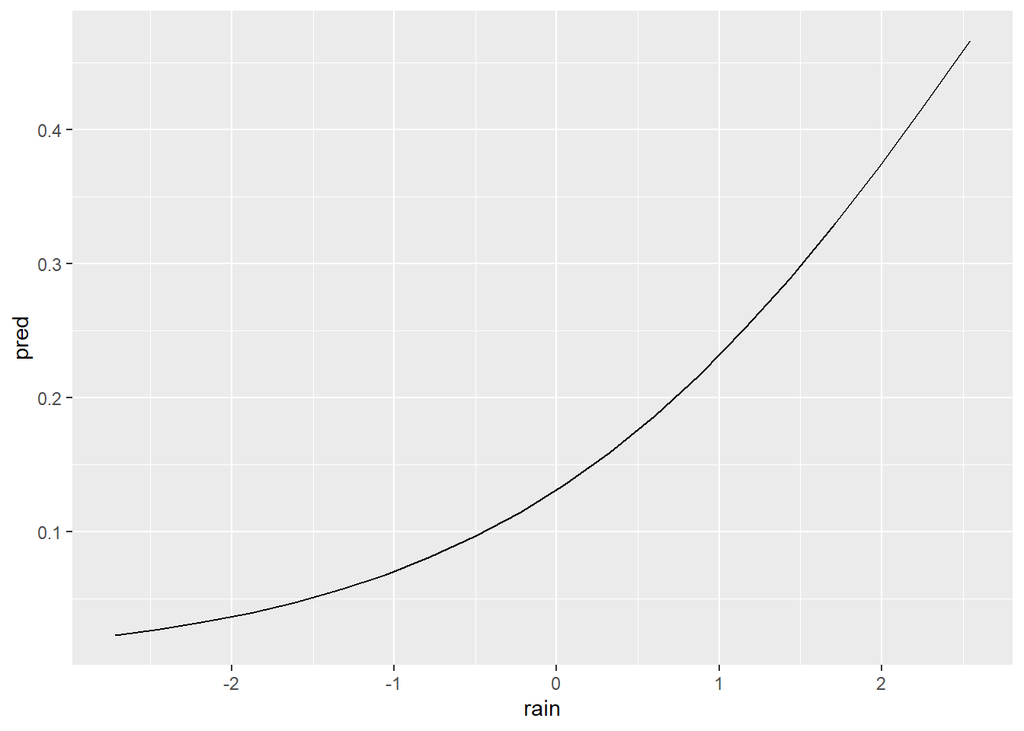

```r
df <- data.frame(
  pred,
  rain
)

ggplot(df) +
  geom_line(aes(x = rain, y = pred))
```

From this figure it now appears much more intuitive that increasing rain makes elephants easier to detect. We can do a little “tidying” of the figure to make it more visually pleasing:

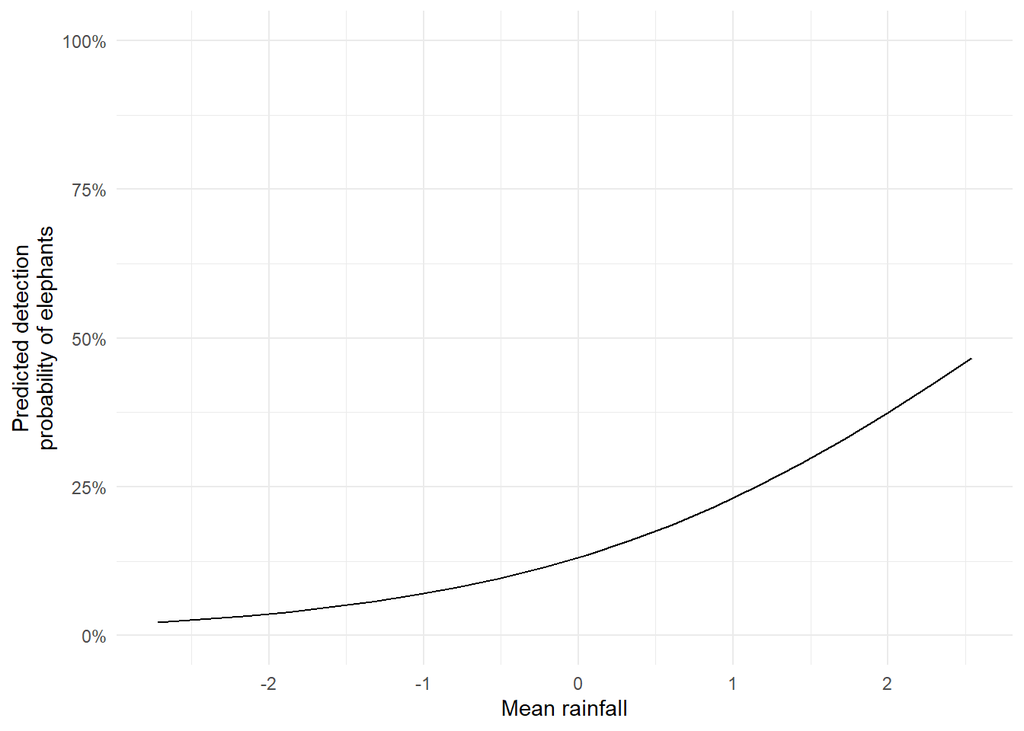

```r
ggplot(df) +
  geom_line(aes(x = rain, y = pred)) +
  scale_y_continuous(labels = scales::percent,
                     limits = c(0,1)) +
  theme_minimal() +
  labs(x = "Mean rainfall",
       y = "Predicted detection\nprobability of elephants")
```

# Uncertainty

The above figure is a good start but we’re missing any measure of uncertainty. If we were doing frequentist statistics, we would use 95% confidence intervals but these are exclusively frequentist. There are no 95% confidence intervals when we use the Bayesian statistical framework. Instead we have *credible intervals*. I’ll explain the Bayesian framework in a subsequent workflow but for now here is the formal definition of a credible interval:

> There is a 95% probability that the **True** parameter value lies within the interval range, given the data and model.

This is in contrast with the frequentist confidence interval whose formal definition is so bizarre and unintuitive that it’s barely useful. 95% *credible intervals* are useful and work exactly the way people *think* frequentist intervals work.

But how do we include these in the figure? Well, the model summary makes it easy to find the values:

```r
summary(fit)
```

```
##
## Call:
## PGOcc(occ.formula = ~1, det.formula = ~rain, data = etosha, n.samples = 2000,
##     verbose = FALSE, n.burn = 200, n.chains = 4)
##
## Samples per Chain: 2000
## Burn-in: 200
## Thinning Rate: 1
## Number of Chains: 4
## Total Posterior Samples: 7200
## Run Time (min): 0.0162
##
## Occurrence (logit scale):
##               Mean     SD   2.5%   50%  97.5%   Rhat ESS
## (Intercept) 1.8753 0.9465 0.3078 1.772 4.0465 1.0516 349
##
## Detection (logit scale):
##                Mean     SD    2.5%     50%   97.5%   Rhat  ESS
## (Intercept) -1.8872 0.2946 -2.4610 -1.8939 -1.2939 1.0165 1038
## rain         0.6930 0.2384  0.2328  0.6877  1.1801 1.0025 2604
```

They’re the `2.5%` and `97.5%` values in our summary table. So all we need to do is repeat our predicions using these values to get out measure of uncertainty to include in the figure. Importantly, if you remember back to BI3010 where you had to multiple standard error by 1.96, we *do not* need to do that here. That’s frequentist nonsense - we’re Bayesian now.

Let’s do just that:

```r
df$low <- plogis(-2.4610 + 0.2328 * df$rain)
df$upp <- plogis(-1.2939 + 1.1801 * df$rain)
df
```

```
##          pred        rain        low        upp
## 1  0.02263134 -2.71815687 0.04336427 0.01096960
## 2  0.02726568 -2.44127881 0.04611831 0.01514457
## 3  0.03281714 -2.16440076 0.04903828 0.02087495
## 4  0.03945308 -1.88752271 0.05213304 0.02871039
## 5  0.04736516 -1.61064465 0.05541172 0.03936862
## 6  0.05677017 -1.33376660 0.05888379 0.05376451
## 7  0.06790956 -1.05688855 0.06255900 0.07302436
## 8  0.08104689 -0.78001049 0.06644741 0.09846565
## 9  0.09646267 -0.50313244 0.07055932 0.13151304
## 10 0.11444547 -0.22625439 0.07490526 0.17351714
## 11 0.13527876  0.05062367 0.07949599 0.22545433
## 12 0.15922259  0.32750172 0.08434241 0.28752905
## 13 0.18649040  0.60437977 0.08945559 0.35877811
## 14 0.21722152  0.88125783 0.09484663 0.43685701
## 15 0.25145143  1.15813588 0.10052670 0.51819600
## 16 0.28908330  1.43501393 0.10650691 0.59858193
## 17 0.32986526  1.71189199 0.11279825 0.67399363
## 18 0.37337882  1.98877004 0.11941156 0.74135968
## 19 0.41904309  2.26564809 0.12635738 0.79895748
## 20 0.46613767  2.54252615 0.13364590 0.84638633
```

And we can add in our uncertainty using `geom_ribbon()`:

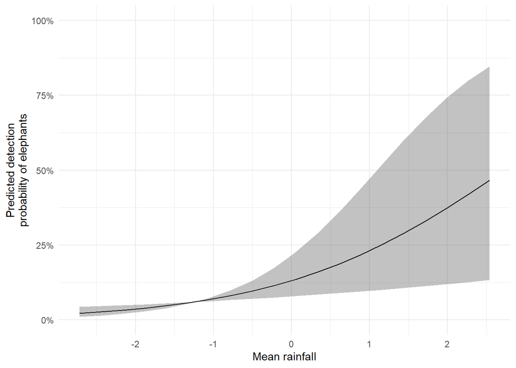

```r
ggplot(df) +
  geom_line(aes(x = rain, y = pred)) +
  geom_ribbon(aes(x = rain, ymin = low, ymax = upp),
              alpha = 0.3) +
  scale_y_continuous(labels = scales::percent,
                     limits = c(0,1)) +
  theme_minimal() +
  labs(x = "Mean rainfall",
       y = "Predicted detection\nprobability of elephants")
```

With that, we have a publication ready figure.

# Multiple covariates

Let’s increase the complexity a bit and have the simulation include multiple covariates. We’ll say that tree height and average temperature affect whether or not a site is occupied (elephants will like tall trees and cooler locations). We’ll still have rain affect our detection probability, as above.

To create the figures below we need to do some tweaks to the data. The `df` object I create has one row per survey, with three surveys per site. Our occupancy covariates, `tree` and `temp` have just one value; these do not change from one survey to the next. If a tree is 3 m tall in survey one, then it’ll still be 3 m tall in surveys two and three.

A note here is that the covariates are still centered on zero. That’s just the way the data is simulated but the data you collect does not need to be the same (so ignore the fact that we will have trees that are -1 m tall - the general idea doesn’t change).

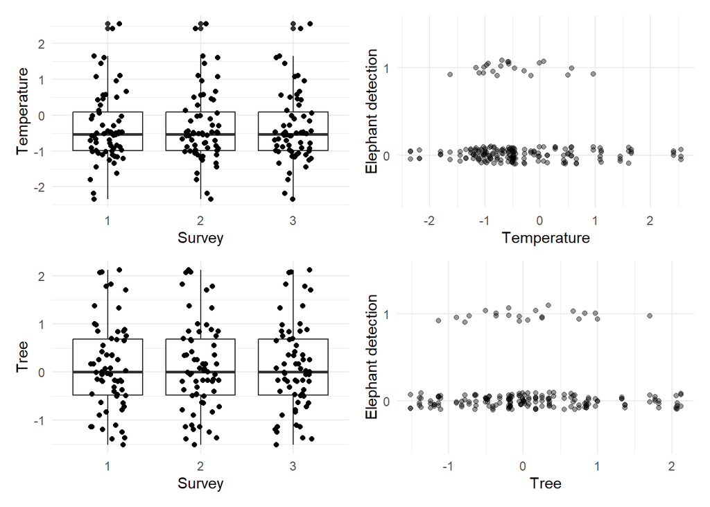

```r
set.seed(1234)
dat <- simOcc(J.x = 8,
              J.y = 8,
              n.rep = rep(3, times = 8 * 8),
              beta = c(1, -0.2, 0.3),
              alpha = c(-2, 0.5))
obs <- dat$y
temp <- dat$X[,2]
tree <- dat$X[,3]
det_cov <- dat$X.p[,,2]
df <- data.frame(
  survey = rep(1:3, each = 64),
  cov = c(det_cov[,1], det_cov[,2], det_cov[,3]),
  tree = rep(tree, times = 3),
  temp = rep(temp, times = 3),
  y = c(obs[,1], obs[,2], obs[,3])
)

p1 <- ggplot(df) +
  geom_boxplot(aes(x = factor(survey), y = temp)) +
  geom_jitter(aes(x = factor(survey), y = temp),
              width = 0.2, height = 0) +
  labs(x = "Survey", y = "Temperature") +
  theme_minimal()

p2 <- ggplot(df) +
  geom_jitter(aes(y = factor(y), x = temp),
              alpha = 0.4, width = 0, height = 0.1) +
  labs(x = "Temperature", y = "Elephant detection") +
  theme_minimal()

p3 <- ggplot(df) +
  geom_boxplot(aes(x = factor(survey), y = tree)) +
  geom_jitter(aes(x = factor(survey), y = tree),
              width = 0.2, height = 0) +
  labs(x = "Survey", y = "Tree") +
  theme_minimal()

p4 <- ggplot(df) +
  geom_jitter(aes(y = factor(y), x = tree),
              alpha = 0.4, width = 0, height = 0.1) +
  labs(x = "Tree", y = "Elephant detection") +
  theme_minimal()

(p1 + p2) / (p3 + p4)
```

This is why we need a model to figure out what the relationships are. We can no longer trust our eyes to see the pattern.

So let’s get our data organised such that we can fit our model.

# Data preparation

```r
det.covs <- list(rain = dat$X.p[,,2])
occ.covs <- data.frame(tree = tree, temp = temp)
etosha <- list(
  y = dat$y,
  det.covs = det.covs,
  occ.covs = occ.covs
)
```

# Fitting the model

The core model we’re going to fit is:

$$z_i \sim Bernoulli(\psi_i)\\
logit(\psi_i) = \beta_0 + \beta_1 \times Tree_i + \beta_2 \times
Temp_i\\
y_{i,j} \sim Bernoulli(p_{i,j} \times z_i)\\
logit(p_{i,j}) = \alpha_0 + \alpha_1 \times Rain_{i,j}$$

The main thing that I want to highlight here, other than having included $Tree$ and $Temp$ as effecting occupancy probability ($\psi$), is that the subscripts are different.

But in the detection model ($logit(p_{i,j}) = \alpha_0 + \alpha_1 \times Rain_{i,j}$) $Rain$ is subscript by both $i$ and $j$. That’s because we have a different $Rain$ value for each survey. This would be something we record every time we visit the site (or extract from some online source for each day).

Keep this in mind when you’re collecting your own data. Variables that you think affect occupancy will have one value per site. Variables that you think affect detection will (generally) have one value per survey.

To fit this is relatively straight forward. For the occupancy model, we write `occ.formula = ~ tree + temp`, and for the detection model we write `det.formula = ~ rain`, and let the machinery do it’s thing.

```r
fit <- PGOcc(
  occ.formula = ~ tree + temp,
  det.formula = ~ rain,
  data = etosha,

  # Details to get the machinery to run that we'll ignore for now
  n.chains = 4,
  n.samples = 2000,
  n.burn = 200,
  verbose = FALSE)
```

Once it’s run, we can check the `summary()` to see what the parameters were estimated as:

```r
summary(fit)
```

```
##
## Call:
## PGOcc(occ.formula = ~tree + temp, det.formula = ~rain, data = etosha,
##     n.samples = 2000, verbose = FALSE, n.burn = 200, n.chains = 4)
##
## Samples per Chain: 2000
## Burn-in: 200
## Thinning Rate: 1
## Number of Chains: 4
## Total Posterior Samples: 7200
## Run Time (min): 0.0172
##
## Occurrence (logit scale):
##                Mean     SD    2.5%     50%  97.5%   Rhat ESS
## (Intercept)  1.9424 1.0250  0.1512  1.8670 4.0917 1.0187 347
## tree         0.3904 1.3242 -2.0614  0.3232 3.0704 1.0196 267
## temp        -1.2186 1.0959 -3.2786 -1.2776 1.1046 1.0246 267
##
## Detection (logit scale):
##                Mean     SD    2.5%     50%   97.5%   Rhat  ESS
## (Intercept) -1.8408 0.2706 -2.3623 -1.8447 -1.2875 1.0066 1117
## rain         0.1666 0.2196 -0.2592  0.1611  0.6073 1.0038 3054
```

So we’ve got the general relationships reasonably well estimated but it’s not particularly accurate. This is where having *credible intervals* is useful. Keep in mind that credible intervals are, correctly, interpreted as having a 95% chance of containing the “True” value (the True value here is what each parameter was set to in the simulation). For both `tree` and `temp` the True parameter value is indeed within the 95% credible intervals! Both 95% CI are wide, but that’s good here! The model isn’t entirely sure what the values are (partly because of sample size and the effects being subtle) and that is being conveyed to us! We’re not deluding ourselves into thinking we have a perfect understanding when we don’t!

There are some other warning signs that the model might not be performing especially well. The first is that the `Rhat` values are getting uncomfortably large for the `Occurence` parameters. My personal rule of thumb is `Rhat` values close to 1.05 is where I get worried. None of our parameters are at 1.05 but they’re close enough that I’m paying attention to them and want to see if I can fix the problem.

The other warning sign is the `ESS` for the `Occurence` model are all “low”. At least noticeably lower than the `Detection` model parameters. Again, the rule of thumb here is that we want hundreds or thousands of “Effective Sample Size”, so we’re technically OK but I’m still concerned.

Now, to be clear, we ignored these issues with the first model we ran in this document, we here we’re going to see if we can’t resolve this problem.

# Resolving issues

To fully appreciate the solution we’ll attempt requires a deeper understanding of Bayesian statistics. But for now, we’re not going to cover this. Instead, I’ll simply say that the “machinery” of Bayesian statistics revolves around giving a number of algorithms (called “chains”) a number of guesses (called “iterations”) to try and figure out the most likely values for our parameters.

The two metrics we used above, `Rhat` and `ESS`, both monitor these chains and iterations and let us know if they are *not in agreement*. When `Rhat` values get high, and `ESS` values get low, it can suggests we simply need to give the algorithms more iterations to figure out the best values.

Inevitably, the details are more complex than I can convey in two paragraphs but the general idea is there. If either number looks a bit worrying, it’s relatively cheap and easy to just rerun the model with more iterations and see if that solves the problem.

Let’s do just that by increasing the number of iterations to 3000 per chain:

```r
fit <- PGOcc(
  occ.formula = ~ tree + temp,
  det.formula = ~ rain,
  data = etosha,

  # We're using four chains/algorithms
  n.chains = 4,
  # We allow 3000 guesses (increased from 2000)
  n.samples = 3000,
  # We ignore the first 300 (increased from 200)
  # We ignore them because we assume the algorithms are not particularly reliable
  # in the first ca. 10% of guesses
  n.burn = 300,
  verbose = FALSE)
```

Once run, we can check how well they ran:

```r
summary(fit)
```

```
##
## Call:
## PGOcc(occ.formula = ~tree + temp, det.formula = ~rain, data = etosha,
##     n.samples = 3000, verbose = FALSE, n.burn = 300, n.chains = 4)
##
## Samples per Chain: 3000
## Burn-in: 300
## Thinning Rate: 1
## Number of Chains: 4
## Total Posterior Samples: 10800
## Run Time (min): 0.0238
##
## Occurrence (logit scale):
##                Mean     SD    2.5%     50%  97.5%   Rhat ESS
## (Intercept)  2.0655 1.0246  0.1977  2.0138 4.2114 1.0010 529
## tree         0.3721 1.3145 -2.0763  0.3028 3.0319 1.0662 375
## temp        -1.2063 1.1214 -3.3214 -1.2363 1.1050 1.0220 422
##
## Detection (logit scale):
##                Mean     SD    2.5%     50%   97.5%   Rhat  ESS
## (Intercept) -1.8530 0.2644 -2.3777 -1.8521 -1.3301 1.0020 1914
## rain         0.1715 0.2210 -0.2506  0.1682  0.6072 1.0004 4390
```

> Importantly, these are not the only metrics or tools available to us. We’ll check out the other options in a later document.

# Plot predicted relationships

1. Create a “fake” dataset with the covariate values we want to predict for.
2. Apply this fake data to our equation, with the now estimated parameter values, to generate the predictions.
3. Convert from logit values to probabilities.
4. Plot the predicted probabilities against the fake covariate values to show the estimated relationship.

```r
X.0 <- cbind(
  1,
  temp = seq(from = min(occ.covs$temp),
             to = max(occ.covs$temp),
             length.out = 50),
  tree = 0
)

#predict(fit, X.0)
```